# Estadística Descriptiva Multivariada

## Varianza explicada acumulada — los tres canales

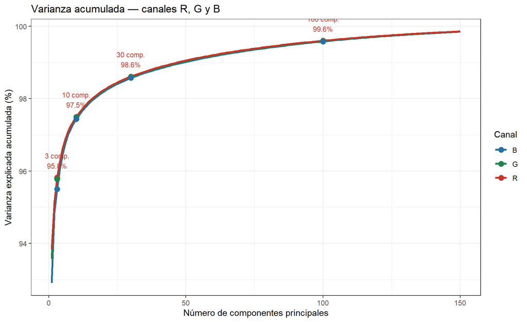

## Reconstrucción progresiva con pocas componentes

- 3 componentes
- 10 componentes
- 30 componentes
- 100 componentes
- Original

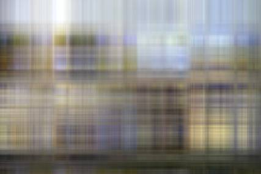

[figure not shown]

[figure not shown]

[figure not shown]

[figure not shown]

# Laboratorio

## Índice de Probreza Multidimensional - IPM

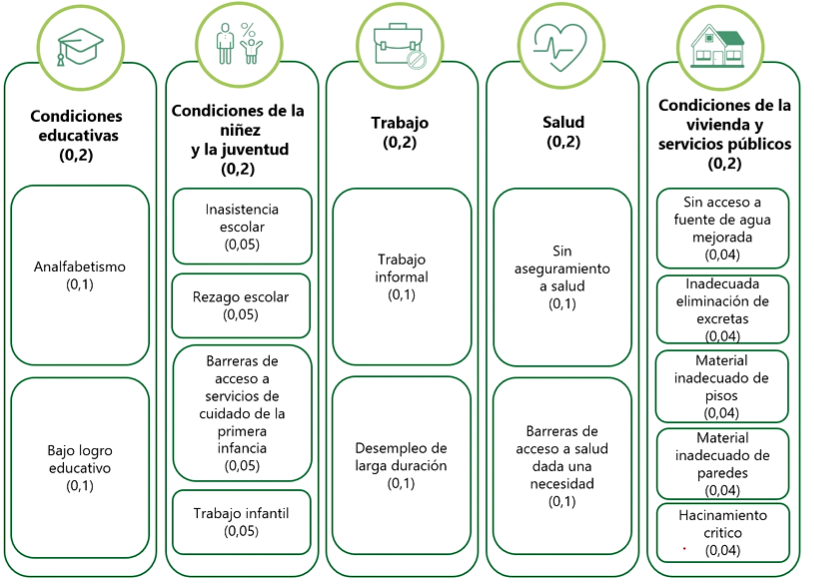

## Asignación por grupos

Cada grupo trabajará con una semilla distinta y con **3 dimensiones del IPM diferentes**.

[output not shown]

## Laboratorio (1/5)

Usando los datos a nivel de hogares del **IPM** de la **Encuesta Nacional de Calidad de Vida (ECV 2025)** disponibles en el portal de microdatos del DANE:

[DANE Microdatos ECV 2025](https://microdatos.dane.gov.co/index.php/catalog/903/get-microdata)

Cada grupo debe usar el siguiente código como referencia para generar el conjunto de datos que va a trabajar. Los códigos deben ser entregados.

## Laboratorio (2/5)

Selección de la muestra de 30.000 hogares.

```r
library(pacman)
p_load(tidyverse, sampling, haven)

ipm <- read_sav("IPM2025.sav")
n_total <- 30000 # Tamaño muestra

# Tamaños por estrato (afijación proporcional)
tam_estrato <- ipm |>
               count(DEPARTAMENTO) |>
               mutate(nh = round(n / sum(n) * n_total))

# Diseño estratificado
set.seed(semilla)
muestra <- strata(data = ipm,
                  stratanames = "DEPARTAMENTO",
                  size = tam_estrato$nh,
                  method = "srswor")

df_ipm <- getdata(ipm, muestra)
```

## Laboratorio (3/5)

1. Calcules los indicadores de las variables del IPM de las dimensiones que le correspondió a nivel de departamento, incluyendo el promedio del IPM y el porcentaje de hogares en condición de pobreza multidimensional.
2. Calcule la matriz de correlaciones entre los indicadores seleccionados.
3. Aplique el ACP usando PCA() de FactoMineR. Compare:
- `scale.unit = TRUE` (sobre $R$)
- `scale.unit = FALSE` (sobre $S$)

¿Cambian los resultados? ¿Por qué?

4. ¿Cuántas componentes retiene cada uno de los tres criterios presentados? Justifique cuál le parece más adecuado para este conjunto de datos.

## Laboratorio (4/5)

5. Construya el **plano 1-2 de variables** con fviz_pca_var(). Identifique:
- Las dos variables con mayor contribución a la Dimensión 1.
- Las dos variables con mayor contribución a la Dimensión 2.
- Una variable con bajo $cos^2$ en el plano 1-2 (mal representada).
6. Construya el **plano de individuos** con fviz_pca_ind() coloreando por $cos^2$. Identifique:
- El departamento con mejor calidad de vida general.
- El departamento peor representado en el plano 1-2.
- Dos departamentos con perfiles similares (cercanos en el plano).
- Dos departamentos con perfiles opuestos (en cuadrantes contrarios).

## Laboratorio (5/5)

7. Genere el **biplot** e interprete qué variable(s) caracterizan al departamento que quedó en el extremo derecho del eje 1.
8. Agregue las variables IPM y porcentaje de hogares en condición de pobreza (sin transformar) como **variables suplementarias** usando quanti.sup. ¿Cómo se ubica en el plano de variables? ¿Qué componente captura mejor la pobreza multidimensional?
9. Repita el ACP con los indicadores de una de las dimensiones como variables suplementarias. ¿Cambia la interpretación de las componentes?
10. **Reto:** Clasifique los departamentos en **4 grupos**.